# Response Summary for Problem Set 4

William W. Chiang

January 5, 2016

Diamonds Data

Notes: Prices of 50,000 round cut diamonds

Description

A dataset containing the prices and other attributes of almost 54,000 diamonds. The variables are as follows:

Usage

data(diamonds) Format

A data frame with 53940 rows and 10 variables

Details

price. price in US dollars ($326–$18,823)

carat. weight of the diamond (0.2–5.01)

cut. quality of the cut (Fair, Good, Very Good, Premium, Ideal)

colour. diamond colour, from J (worst) to D (best)

depth. total depth percentage = z / mean(x, y) = 2 * z / (x + y) (43–79)

table. width of top of diamond relative to widest point (43–95)

### Load ggplot2 package and diamonds dataset

```r
library(ggplot2)
data(diamonds)
```

### Your first task is to create a scatterplot of price vs x. using the ggplot syntax. You can also embed plots, for example:

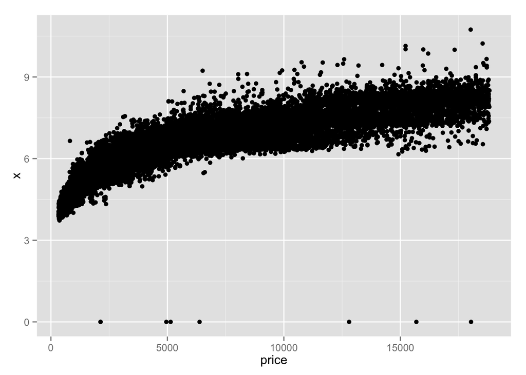

```r
ggplot(aes(x = price, y = x), data = diamonds) +
  geom_point()
```

There is a positive correlation between price and x (diamond length in mm). Furthermore, the rate of x increase is not constant between the low and high end of the price range. Diamond length increases at a greater rate for incremental price increments between 326 (price minimum, summary(diamonds)) and 2500 than prices 2501 and above.

### Load the alr3 package for calculating correlation coefficients

```r
library(alr3)
```

### What is the correlation between price and x?

```r
cor.test(x = diamonds$price, y = diamonds$x)
```

```
##
##  Pearson's product-moment correlation
##
## data:  diamonds$price and diamonds$x
## t = 440.16, df = 53938, p-value < 2.2e-16
## alternative hypothesis: true correlation is not equal to 0
## 95 percent confidence interval:
##  0.8825835 0.8862594
## sample estimates:
##       cor
## 0.8844352
```

### What is the correlation between price and y?

```r
cor.test(x = diamonds$price, y = diamonds$y)
```

```
##
##  Pearson's product-moment correlation
##
## data:  diamonds$price and diamonds$y
## t = 401.14, df = 53938, p-value < 2.2e-16
## alternative hypothesis: true correlation is not equal to 0
## 95 percent confidence interval:
##  0.8632867 0.8675241
## sample estimates:
##       cor
## 0.8654209
```

### What is the correlation between price and z?

```r
cor.test(x = diamonds$price, y = diamonds$z)
```

```
##
##  Pearson's product-moment correlation
##
## data:  diamonds$price and diamonds$z
## t = 393.6, df = 53938, p-value < 2.2e-16
## alternative hypothesis: true correlation is not equal to 0
## 95 percent confidence interval:
##  0.8590541 0.8634131
## sample estimates:
##       cor
## 0.8612494
```

### Create a simple scatter plot of price vs depth

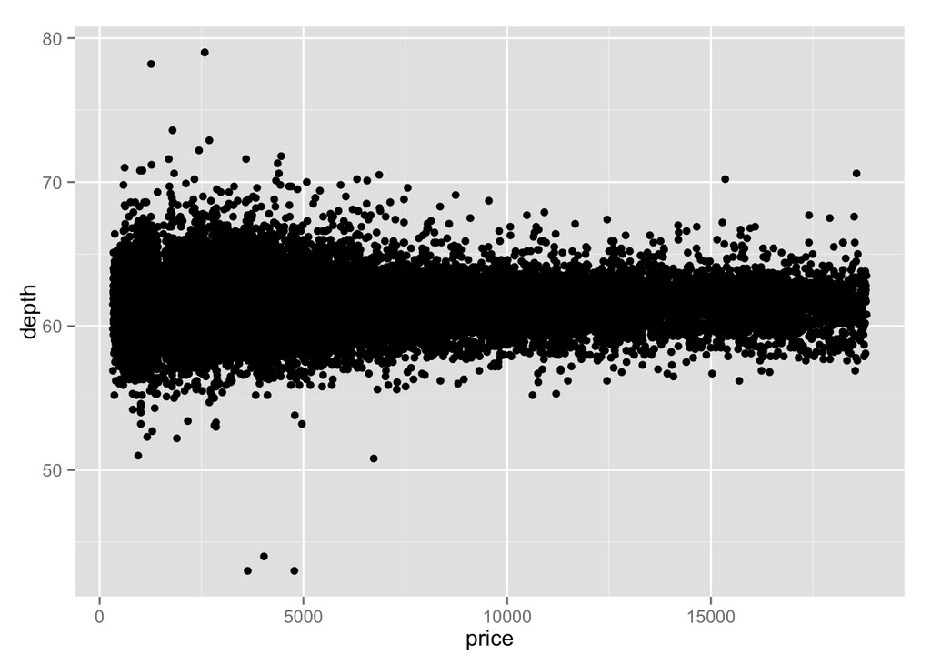

```r
ggplot(aes(x = price, y = depth), data = diamonds) +
  geom_point()
```

### Change the code to make the transparency of the points to be 1/100 of what they are now and mark the x-axis every 2 units

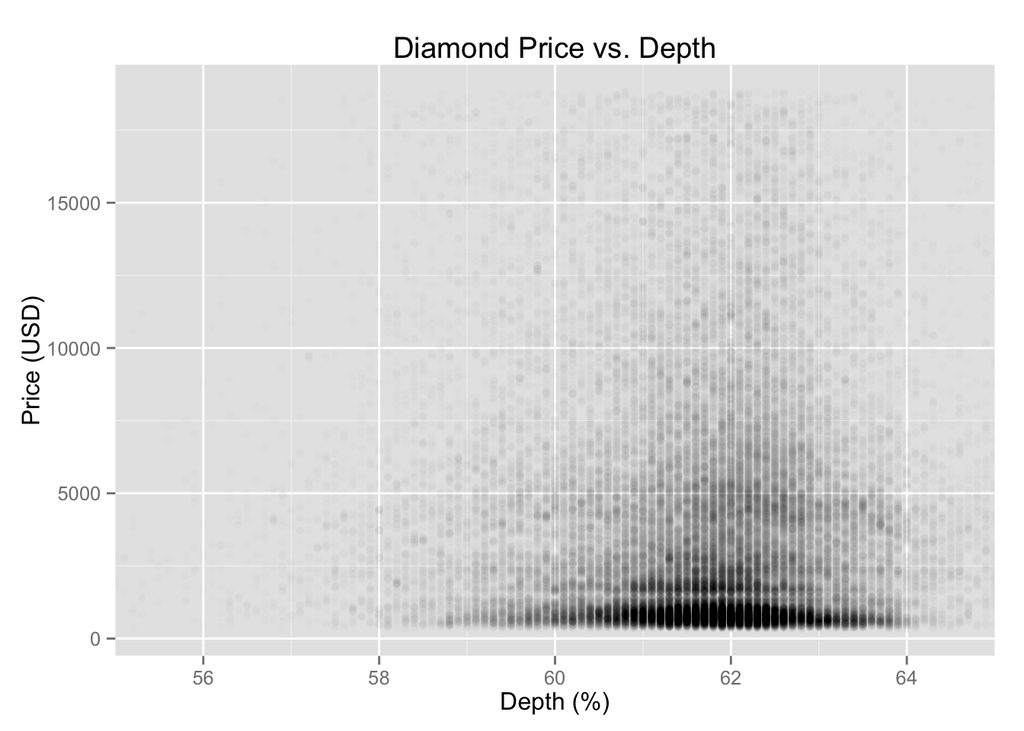

```r
ggplot(aes(x = depth, y = price), data = diamonds) +
     geom_point(alpha = 1/100) +
     scale_x_continuous(breaks = seq(0, 100, 2)) +
     labs(x = "Depth (%)", y = "Price (USD)", title = "Diamond Price vs. Depth") +
     coord_cartesian(xlim = c(55,65))
```

Based on the scatterplot above, most diamonds are between 59 to 63 percent in depth.

### The correlation betwen depth and price can be determine from the r code below.

```r
cor.test(x = diamonds$depth, y = diamonds$price)
```

```
##
##  Pearson's product-moment correlation
##
## data:  diamonds$depth and diamonds$price
## t = -2.473, df = 53938, p-value = 0.0134
## alternative hypothesis: true correlation is not equal to 0
## 95 percent confidence interval:
##  -0.019084756 -0.002208537
## sample estimates:
##        cor
## -0.0106474
```

Result: No correlation between price and depth. Depth should not be used to predict the price of diamond because r was shown to be -0.01, which in absolute terms, is very much below the r = 0.8 significant point.

### Create a scatterplot of price vs carat and omit the top 1% of price and carat values

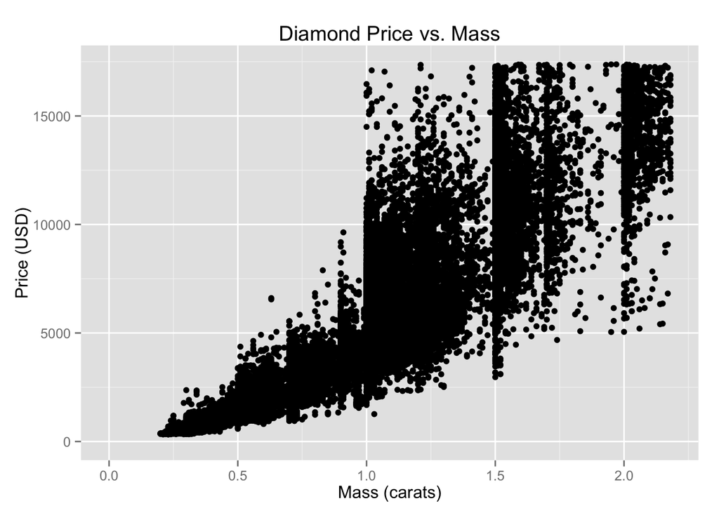

```r
ggplot(aes(x = carat, y = price), data = diamonds) +
  geom_point() +
  scale_x_continuous(limits = c(0, quantile(diamonds$carat, 0.99))) +
  scale_y_continuous(limits = c(0, quantile(diamonds$price, 0.99))) +
  labs(title = "Diamond Price vs. Mass", x = "Mass (carats)", y = "Price (USD)")
```

### Create a new variable for volume in the diamonds data frame

```r
diamonds$volume <- with(diamonds, x * y * z)
```

### Create a scatterplot of price vs. volume (x * y * z)

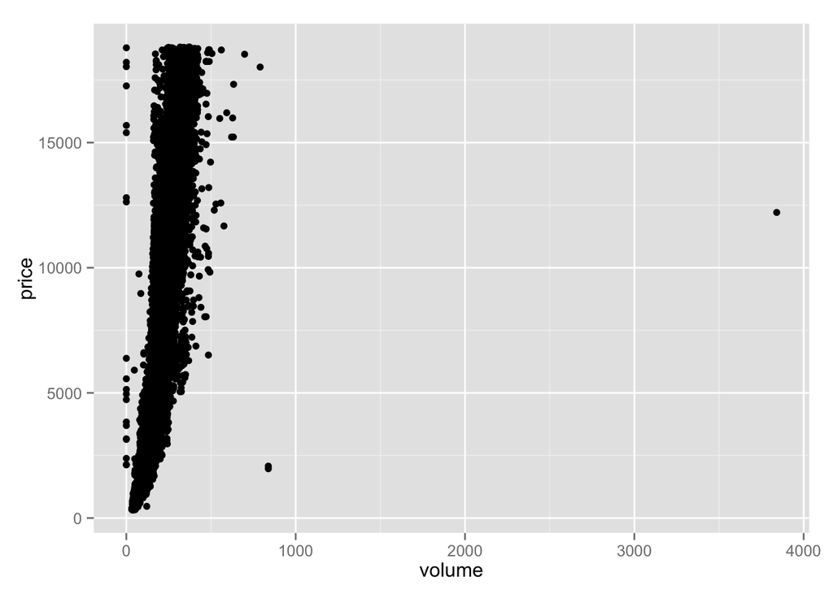

```r
ggplot(aes(x = volume, y = price), data = diamonds) +
  geom_point()
```

Judging the price versus volume scatterplot, there is significant correlation between these two features. *** ### Find the correlation between price and volume, excluding diamonds with volumes of 0 or greater than or equal to 800

```r
with(diamonds[diamonds$volume > 0 & diamonds$volume < 800, ], cor(volume, price))
```

```
## [1] 0.9235455
```

### Subset the data to exclude diamonds with a volume greater than or equal to 800. Also, exclude diamonds with a volume of 0. Adjust the transparency of the points and add a linear model to the plot.

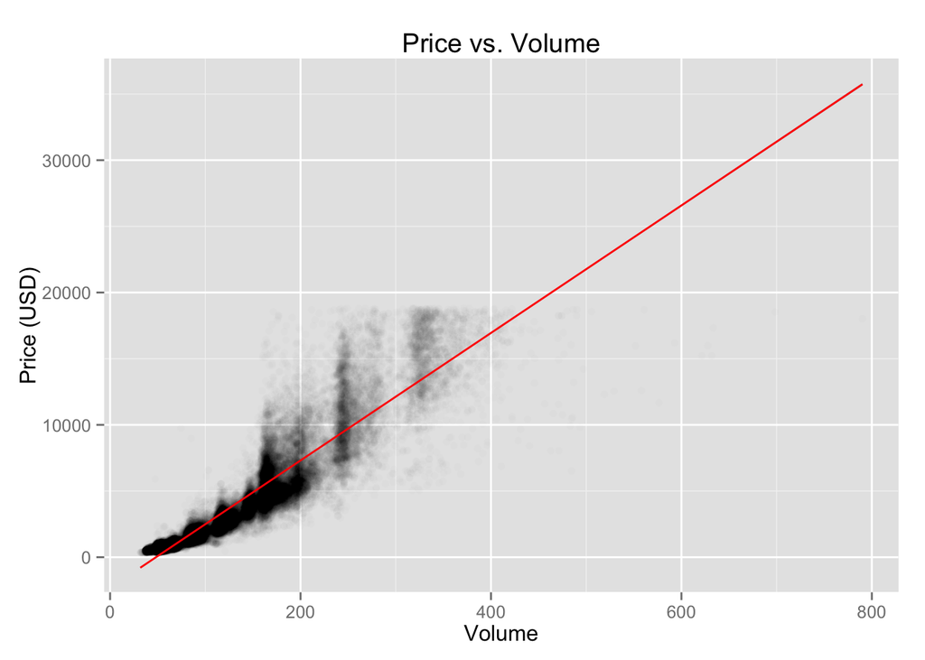

```r
diamonds_subset <- subset(diamonds, volume >0 & volume <= 800)

ggplot(aes(x = volume, y = price), data = diamonds_subset) +
    geom_point(alpha = 1/100) +
    geom_smooth(method = "lm", colour = "red") +
    labs(title = "Price vs. Volume", x = "Volume", y = "Price (USD)")
```

### Use the function dplyr package to create a new data frame containing info on diamonds by clarity, and name the data fram diamondsByClarity

```r
library(dplyr)
diamondsByClarity <- summarise(group_by(diamonds, clarity),
                               mean_price = mean(price),
                               median_price = median(price),
                               min_price = min(price),
                               max_price = max(price),
                               n = n()
                              )

diamondsByClarity
```

```
## Source: local data frame [8 x 6]
##
##   clarity mean_price median_price min_price max_price     n
##    (fctr)      (dbl)        (dbl)     (int)     (int) (int)
## 1      I1   3924.169         3344       345     18531   741
## 2     SI2   5063.029         4072       326     18804  9194
## 3     SI1   3996.001         2822       326     18818 13065
## 4     VS2   3924.989         2054       334     18823 12258
## 5     VS1   3839.455         2005       327     18795  8171
## 6    VVS2   3283.737         1311       336     18768  5066
## 7    VVS1   2523.115         1093       336     18777  3655
## 8      IF   2864.839         1080       369     18806  1790
```

### Bar charts of mean price

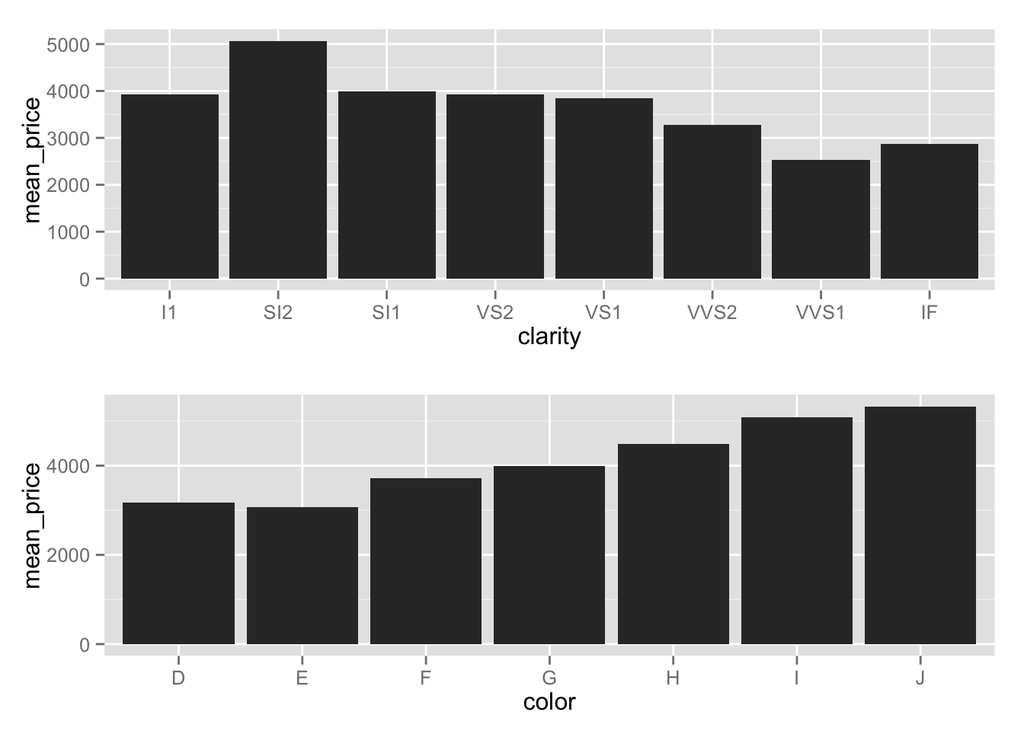

```r
library(gridExtra)

diamonds_by_clarity <- group_by(diamonds, clarity)
diamonds_mp_by_clarity <- summarise(diamonds_by_clarity, mean_price = mean(price))

diamonds_by_color <- group_by(diamonds, color)
diamonds_mp_by_color <- summarise(diamonds_by_color, mean_price = mean(price))

p1 <- ggplot(aes(x = clarity, y = mean_price), data = diamonds_mp_by_clarity) +
  geom_bar(stat = "identity")

p2 <- ggplot(aes(x = color, y = mean_price), data = diamonds_mp_by_color) +
  geom_bar(stat = "identity")

grid.arrange(p1,p2, ncol = 1)
```

Results: Mean price tend to be higher for poorer clarity and color of diamonds!